# Redes, categorías y colaboración

Emergencia y consolidación de la música urbana chilena, 2014–2024

## Autoría y proyecto

**Sebastian Matías Muñoz Tapia**

ANID · Universidad Alberto Hurtado · CMUS

**Fondecyt de Iniciación N.º 11260379**

“Nuevas configuraciones de clase y género en la música urbana chilena: una sociología del gusto generacional”

sebastianmunozt@gmail.com

## Música urbana: una categoría controversial

- La categoría reúne reggaetón, trap, dembow, mambo chileno, RKT y rap, con fronteras variables (Muñoz-Tapia, Arias Salvado y Hammou, 2025).
- En Chile, el rap histórico vinculado al hip hop y al boom bap suele distinguirse de lo reconocido como **urbano** (Muñoz-Tapia y Pinochet-Cobos, 2025).
- Su delimitación implica disputas de pertenencia, generación y legitimidad.

## Música urbana como hipergénero

- Un **hipergénero** agrupa géneros y prácticas heterogéneas bajo una clasificación amplia (Buch, 2013, 2018).
- Su coherencia puede descansar en circuitos, públicos e infraestructuras compartidas, aun con diferencias sonoras.
- Música urbana articula variantes locales y transnacionales como un **hipergénero glocal** (Muñoz-Tapia, Arias Salvado y Hammou, 2025).

## Pregunta central: coherencia y estabilización

**¿Cómo adquiere coherencia y se estabiliza una formación musical tan heterogénea?**

Estudiamos esa estabilización a través de las **colaboraciones entre artistas**.

- ¿Cómo se expande e integra la red?
- ¿Qué fronteras generacionales e internacionales persisten?
- ¿Cómo se distribuye la participación?

## Géneros como procesos de categorización

- Los géneros se producen al **poner nombre a músicas, músicos y públicos**, agrupándolos y diferenciándolos históricamente (Brackett, 2016).
- Esas clasificaciones generan expectativas sobre sonidos, prácticas y pertenencias. Sus fronteras se negocian y disputan (Brackett, 2016; Drott, 2013).
- La categorización se articula con **redes e identidades**: orienta afinidades y las relaciones pueden reforzar o transformar sus significados (Born, 2011; White, 2008; Crossley, 2025a).

## Colaboraciones y estabilización de un mundo musical

- La producción musical descansa en **cooperación y convenciones** (Becker, 2008).
- Los mundos musicales adquieren continuidad mediante relaciones y prácticas recurrentes (Crossley, 2020).
- Las categorías orientan afinidades y las relaciones pueden reforzar o modificar pertenencias (White, 2008; Crossley, 2025a).

**Observamos una dimensión relacional de la estabilización.**

## SNA: análisis de redes sociales

- El **análisis de redes sociales**, o **SNA** por sus siglas en inglés, estudia actores, vínculos y sus configuraciones.
- Permite analizar posiciones centrales y periféricas, integración, agrupamientos y patrones de asociación.
- En el estudio de mundos musicales, complementa la historia con evidencia sobre **quién coopera con quién y cómo se organiza esa cooperación** (Crossley, 2020, 2025a).

Aquí combinamos **descriptivos, comunidades y ERGM**.

## Dos períodos de observación

| Formación y consolidación nacional | Boom y expansión internacional |
| --- | --- |
| Enero de 2014 a febrero de 2022 | Marzo de 2022 a diciembre de 2024 |
| Articulación de trayectorias y circuitos locales | Mayor escala y visibilidad transnacional |

**Redes independientes:** cada período conserva sus propias colaboraciones.

## Qué representa la red

[figure not shown]

**Ejemplo ficticio.** Coparticipaciones acreditadas en Spotify. Núcleo chileno validado manualmente y colaboradores directos, con filtro de más de 1.000 seguidores.

## Red de formación y consolidación nacional

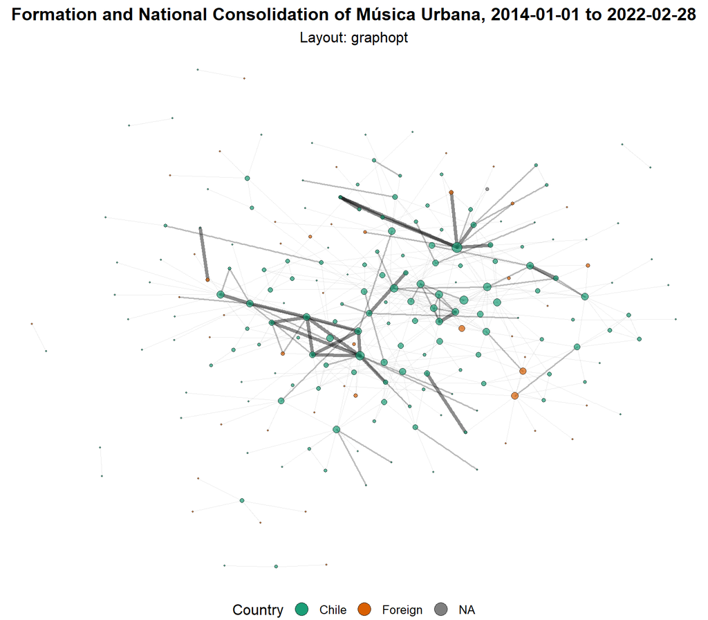

La red reúne **213 artistas y 410 vínculos**. El componente mayor contiene al **89,7 %** de los artistas (disertación, 2026, tabla 2A).

## Red del boom y expansión internacional

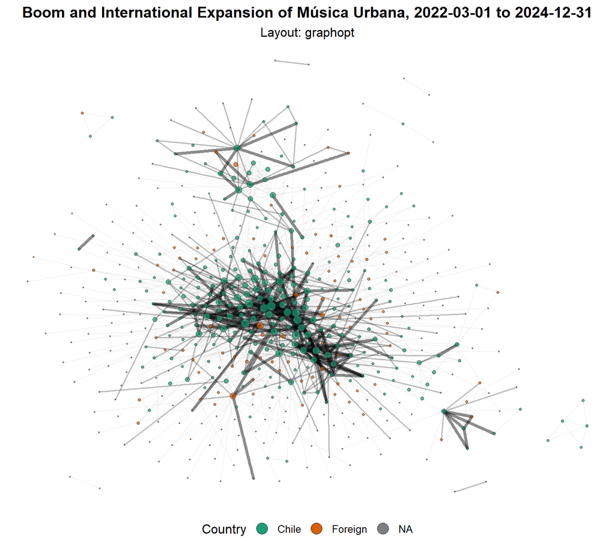

La red llega a **564 artistas y 1.579 vínculos**. El componente mayor alcanza el **96,6 %** (disertación, 2026, tabla 2A).

## La integración conserva una periferia amplia

| Colaboradores por artista | Formación | Boom |
| --- | --- | --- |
| Promedio | 3,85 | 5,60 |
| Mediana | 2 | 2 |
| Máximo | 27 | 55 |

**El promedio aumenta, pero la mitad de los artistas tiene como máximo dos colaboradores.**

## Aumentan las colaboraciones recurrentes

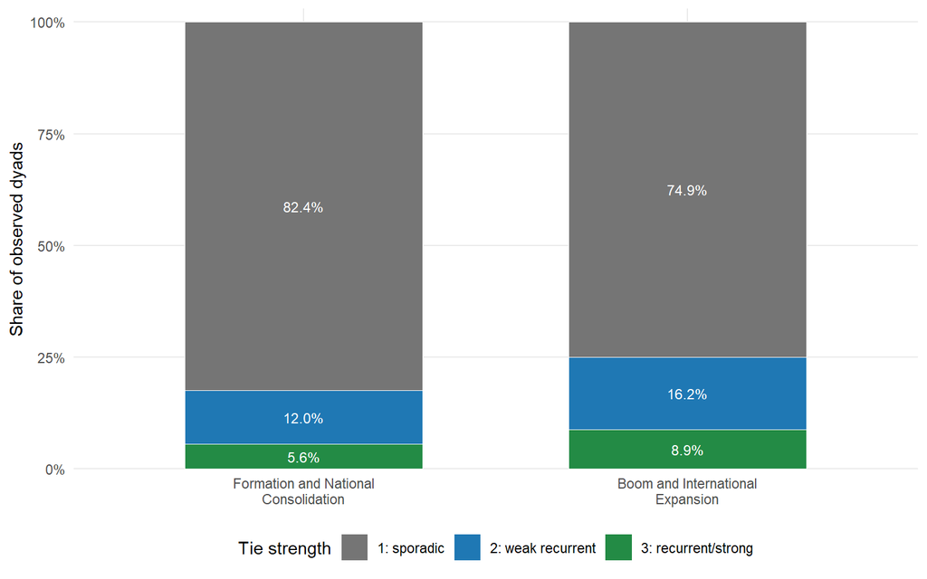

Las parejas con **dos o más pistas** pasan del **17,6 % al 25,1 %**. Predominan los vínculos de una sola pista (disertación, 2026, figura 5).

## Conclusiones de los descriptivos

- **Integración:** más artistas forman parte de una estructura conectada.
- **Continuidad:** aumenta la proporción de colaboraciones recurrentes.
- **Desigualdad:** la participación típica sigue siendo reducida, con mediana de dos colaboradores.

La estabilización relacional combina **integración y recurrencia**, conservando diferencias de participación (disertación, 2026, pp. 23–30).

## Comunidades: qué hace el método Leiden

- Una comunidad reúne artistas con **más peso de colaboración interno del esperado según su conectividad**.
- Leiden busca una partición que optimice la **modularidad ponderada** del componente mayor.
- Utilizamos pesos ordinales: **una, dos y tres o más pistas**.
- Comparamos resoluciones y ejecuciones, y contrastamos con Louvain: ajuste, estabilidad, tamaños e interpretación (disertación, 2026, pp. 30–34).

## Comunidades durante la formación

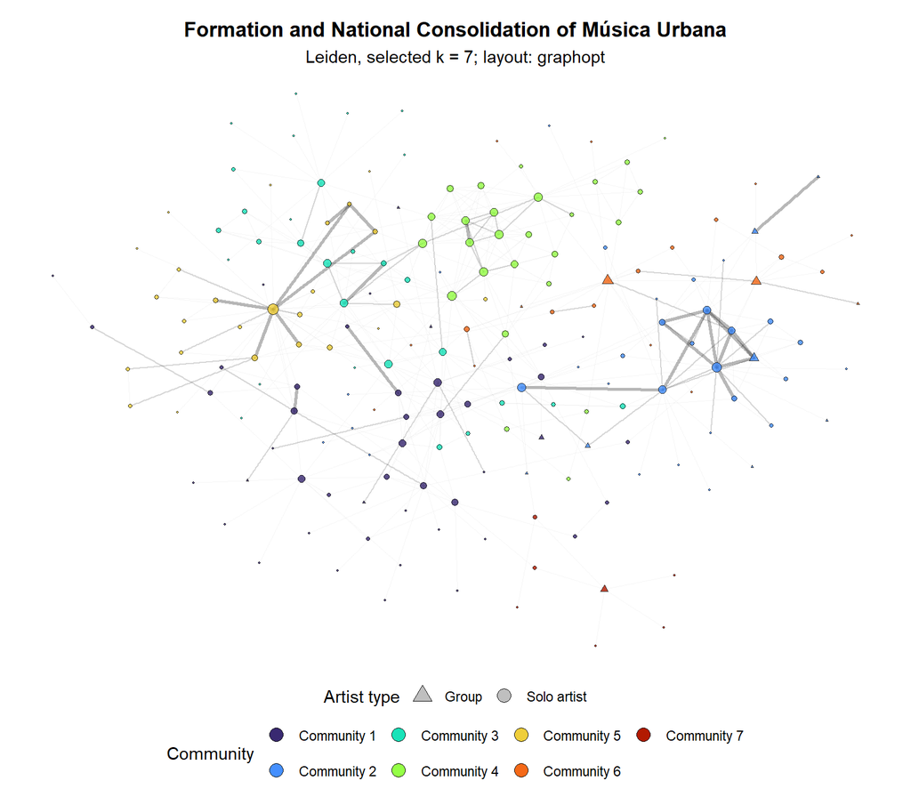

La partición identifica **siete comunidades**. La diferenciación relacional dialoga con las divisiones generacionales de la escena (Muñoz-Tapia y Pinochet-Cobos, 2025).

## Comunidades durante el boom

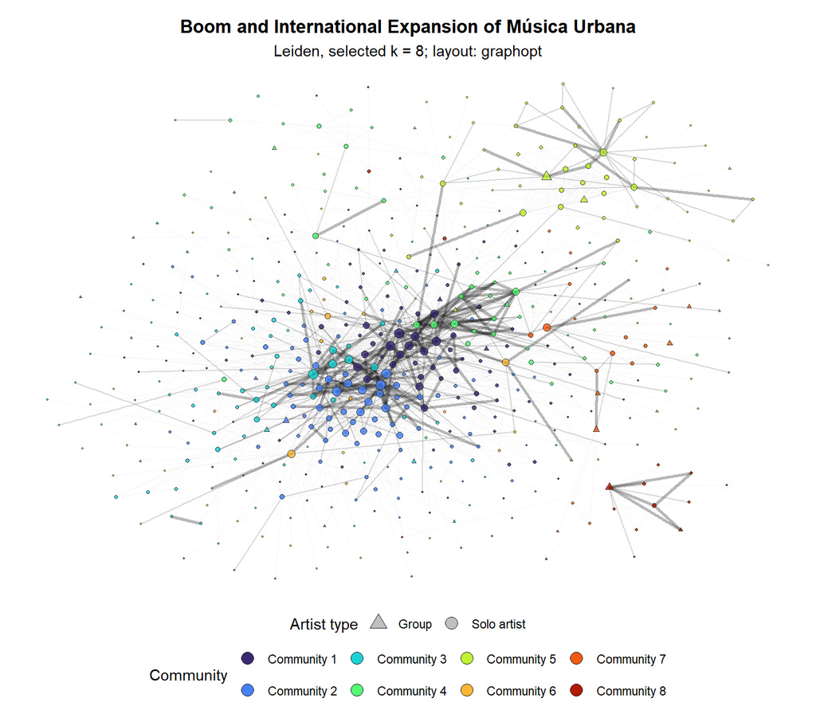

La partición identifica **ocho comunidades** dentro de una red mayor. Los números y colores son específicos de cada período (disertación, 2026, sección 5.2).

## Comunidades: comparación entre períodos

| Dimensión | P1: formación | P2: boom |
| --- | --- | --- |
| Partición Leiden | 7 comunidades, 191 artistas | 8 comunidades, 545 artistas |
| Rap | C2 y C6: predominan inicios en los años 1990 | C5: rap histórico; C8: cohorte dominante 2005–2009 |
| Urbano reciente | Predominan inicios entre 2015 y 2019 | C1, C2, C3 y C6: predominan inicios entre 2020 y 2024 |
| Lectura | Diferenciación generacional visible | Mayor escala, con diferencias internas persistentes |

La comparación es de **perfiles y configuraciones**, no de grupos idénticos seguidos en el tiempo (disertación, 2026, pp. 33–41).

## Comunidades: apertura internacional y articulaciones locales

| Dimensión | P1: formación | P2: boom |
| --- | --- | --- |
| Articulación internacional | C5: Pablo Chill-E y Julianno Sosa, conexiones transnacionales tempranas | C1: 62 % extranjeros; C6: 90 %, con fuerte conexión a circuitos argentinos |
| Colaboración recurrente | C4: destaca la intensidad en reggaetón y mambo | C2: mayor intensidad media ordinal, con 117 artistas y 21 % extranjeros |
| Mujeres y grupos mixtos | C2: 27 %, con conexiones alrededor de Ana Tijoux | C4: 29 %, con AKRIILA, Shirel, SOULFIA y otras |

La expansión combina **núcleos internacionales y circuitos locales intensos** (disertación, 2026, pp. 37–40).

## Conclusiones de las comunidades

- La red pasa de siete a ocho comunidades en un componente mayor mucho más amplio.
- Persiste la diferenciación entre rap y urbano, con nuevas cohortes y configuraciones.
- La apertura internacional convive con circuitos nacionales de colaboración intensa.

El hipergénero articula diferencias **sin suprimir sus fronteras internas** (Muñoz-Tapia y Pinochet-Cobos, 2025; Muñoz-Tapia, Arias Salvado y Hammou, 2025).

## La internacionalización es selectiva

- En la disertación (2026, pp. 28 y 51), la presencia extranjera sube del **21,2 % al 38,9 %**, pero el modelo conserva una asociación negativa para vínculos Chile–extranjero.
- La expansión internacional se concentra en comunidades específicas.
- Una mayor circulación musical puede coexistir con desigualdades persistentes (Hesmondhalgh, 2025).

## ERGM: qué queremos explicar

- Preguntamos **qué patrones se asocian con que dos artistas colaboren**, considerando atributos y estructura de la red.
- Para cada pareja elegible registramos **1 = al menos una colaboración** y **0 = ninguna** en el período.
- Estimamos una red por período. La frecuencia de colaboración queda en el análisis descriptivo.
- El ERGM contrasta la red observada con una distribución de redes posibles (Koskinen y Snijders, 2012).

## ERGM: construcción y selección del modelo

| Paso | Qué incorporamos |
| --- | --- |
| **M1** | Nivel general de vínculos y restricciones del diseño |
| **M2** | Diferencia entre años de inicio y vínculos Chile–extranjero |
| **M3** | Similitud de género y de tipo de artista |
| **M4** | Presencia de artistas con un único colaborador |

Seleccionamos **M4** por su mejor AIC y BIC en ambos períodos y evaluamos su ajuste mediante redes simuladas (disertación, 2026, pp. 43–50).

## ERGM: cómo interpretar un coeficiente

- El coeficiente actúa sobre las **log-odds condicionales** de un vínculo: depende de la red y de los demás términos.
- Para un atributo de pareja, **exp(β)** expresa un multiplicador de odds, con el resto constante.
- Ejemplo del boom: **β = −1,00** para Chile–extranjero implica **exp(−1) ≈ 0,37** veces las odds de Chile–Chile.
- Esto equivale a un 63 % menos de **odds**, no de probabilidad (disertación, 2026, tabla 7B).

## ERGM: lectura de los coeficientes

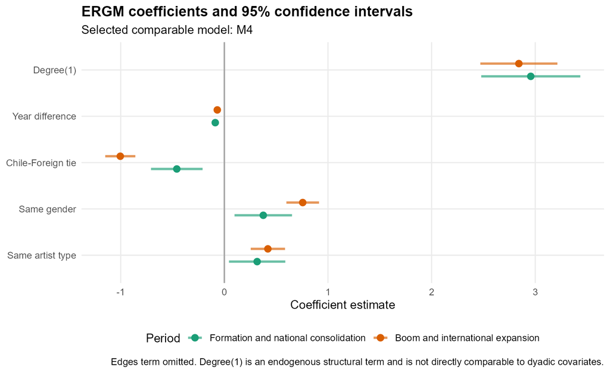

Los puntos son estimaciones y las líneas sus intervalos del 95 %. El cero marca ausencia de asociación para el término estimado. Verde: formación. Naranja: boom (disertación, 2026, figura 8).

## Conclusiones del ERGM

- **Proximidad generacional:** colaborar se asocia con trayectorias iniciadas en años cercanos.
- **Internacionalización selectiva:** los vínculos Chile–extranjero siguen siendo menos probables que los Chile–Chile, dentro del modelo.
- **Periferia persistente:** M4 representa mejor la abundancia de artistas con un solo colaborador.
- **Límite:** las simulaciones subestiman los vecinos compartidos. La cohesión local requiere otras evidencias (disertación, 2026, pp. 50–52).

## Género y participación localizada

- Los artistas masculinos representan cerca del **88 %** en ambos períodos.
- Las comunidades muestran presencias desiguales de mujeres y agrupaciones mixtas.
- Ana Tijoux articula conexiones relevantes en el segmento de rap histórico.
- La música participa en la materialización de identidades sociales (Born, 2011).

## Alcance de los hallazgos

- Spotify registra una capa de relaciones acreditadas y visibles.
- El filtro de seguidores y la selección del núcleo delimitan quién aparece.
- Las ventanas desiguales y los cambios de cobertura limitan la comparación del crecimiento.
- Los modelos identifican asociaciones y tienen límites para representar la cohesión local.

## Conclusiones: respuestas a las preguntas

1. **Estructura:** la red crece y reúne a más artistas en un componente común, con una periferia amplia.
2. **Internacionalización:** aumenta la presencia extranjera, concentrada en circuitos específicos.
3. **Participación:** crece la recurrencia, pero la mediana permanece en dos colaboradores.

## Conclusiones: estabilización de un hipergénero

- Las comunidades extienden al plano relacional la historia generacional de la música urbana chilena (Muñoz-Tapia y Pinochet-Cobos, 2025).
- El hipergénero adquiere continuidad mediante colaboraciones, mientras conserva diferencias y controversias internas (White, 2008; Crossley, 2025a).

**¿Cómo se relacionan estas fronteras con las pertenencias que reconocen los propios artistas?**

## El aporte de los métodos mixtos

- El **SNA y su dimensión cuantitativa** permitieron identificar las estructuras de colaboración y examinar variables asociadas a los procesos de categorización musical.
- La **investigación histórico-etnográfica** permitió interpretar estos patrones y comprender los sentidos que los actores atribuyen a sus relaciones y categorías.
- El análisis cuantitativo también reveló **agrupaciones que no habían sido identificadas en el trabajo histórico-etnográfico**, lo que permitió situar sus hallazgos en una estructura relacional más amplia.
- **Alcance y límite del SNA:** esta red observa una relación específica: la colaboración acreditada en canciones. Su articulación con el análisis histórico-etnográfico permite comprender otras relaciones que intervienen en la categorización musical y que no quedan registradas en esos vínculos.

## Referencias de consulta I

Becker, H. S. (2008). *Los mundos del arte: Sociología del trabajo artístico*. Universidad Nacional de Quilmes.

Born, G. (2011). Music and the materialization of identities. *Journal of Material Culture, 16*(4), 376–388.

Brackett, D. (2016). *Categorizing Sound: Genre and Twentieth-Century Popular Music*. University of California Press.

Crossley, N. (2020). *Connecting Sounds: The Social Life of Music*. Manchester University Press.

Crossley, N. (2025a). Group formation and social structure: On networks and identities. *Acta Sociologica*, 00016993251357717.

Drott, E. (2013). The end(s) of genre. *Journal of Music Theory, 57*(1), 1–45.

## Referencias de consulta II

Hesmondhalgh, D. (ed.). (2025). *Music Streaming Around the World*. University of California Press.

Muñoz-Tapia, S., Arias Salvado, M. y Hammou, K. (2025). Urban music, hurban y música urbana: Falsos amigos, afinidades electivas y procesos de categorización de un hipergénero glocal. Introducción al dossier «música urbana: Masificación y cambios sociales de un campo en disputa». *Resonancias, 29*(57), 13–27.

Muñoz-Tapia, S. y Pinochet-Cobos, C. (2025). Géneros musicales y generaciones: La conformación controversial de la música urbana chilena. *Latin American Music Review, 46*(1), 102–131.

White, H. C. (2008). *Identity and Control: How Social Formations Emerge* (2.ª ed.). Princeton University Press.

**Fuente de los resultados:** *Networks, Categories, and Collaboration: The Emergence and Consolidation of Chilean Música Urbana* (2026). Disertación de MSc Social Network Analysis, University of Manchester, identificador 14340176. El PDF no consigna nombre de autor en la portada.

## Respaldo: composición de la red

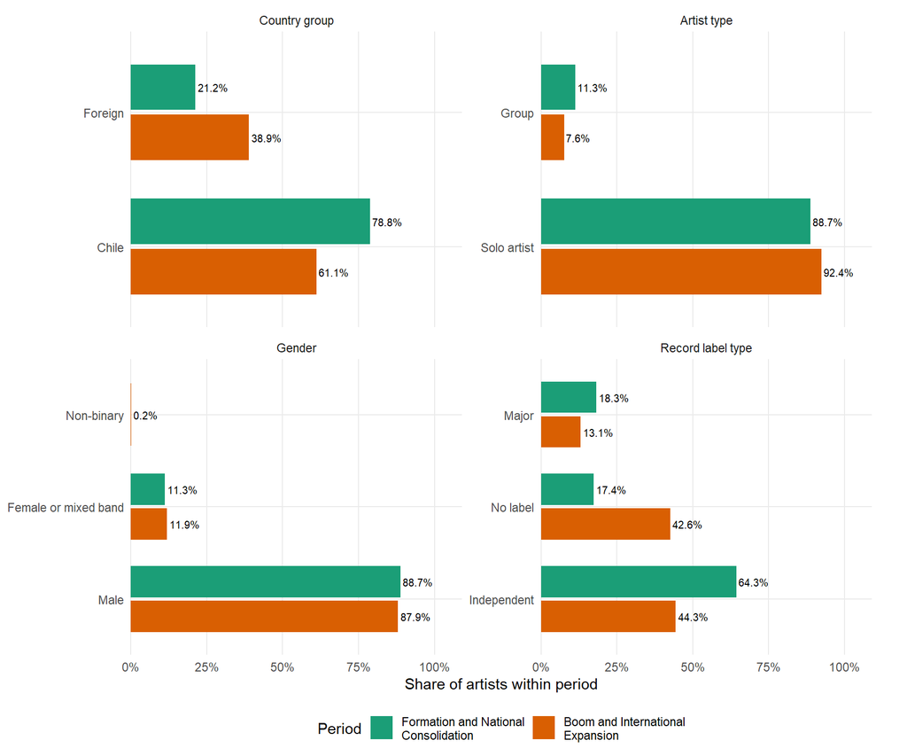

## Respaldo: generaciones de ingreso

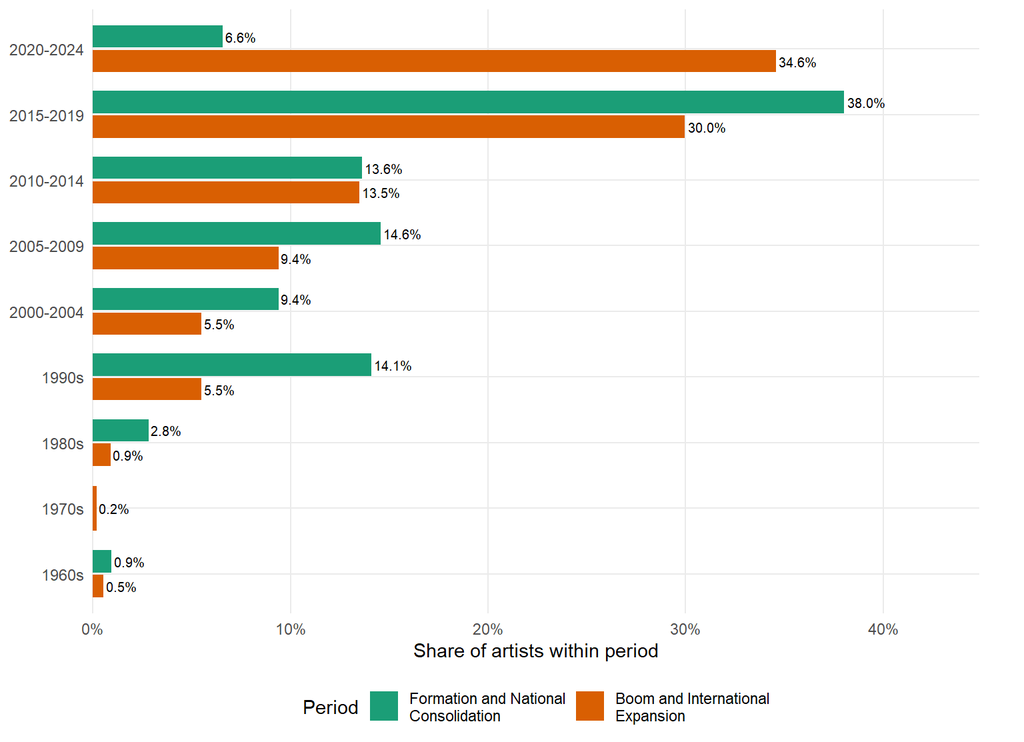

## Referencia metodológica del ERGM

Koskinen, J. y Snijders, T. A. B. (2012). Simulation, estimation, and goodness of fit. En D. Lusher, J. Koskinen y G. Robins (eds.), *Exponential Random Graph Models for Social Networks: Theory, Methods, and Applications*. Cambridge University Press.

## Referencias sobre hipergénero

Buch, E. (2013). Le duo de la musique savante et la musique populaire: Genres, hypergenres et sens commun. En E. Pedler y J. Cheyronnaud (eds.), *Théories ordinaires*. Éditions de l’EHESS.

Buch, E. (2018). La musique classique est-elle un genre? Quelques remarques sur les pratiques de catégorisation à l’ère numérique. En S. Dorin (ed.), *Déchiffrer les publics de la musique classique: Perspectives comparatives, historiques et sociologiques*. Éditions des Archives Contemporaines.